# Tightening the Grid on Fire Effects Using NEON 1-m LiDAR and Hyperspectral Reflectance Datasets: A Case Study of the 2016 Chimney Tops 2 Wildfire, Great Smoky Mountains National Park, USA

### Authors: Eric Gottlieb and Heidi Yoon

### Project Partner: Dr. Nayani Ilangakoon, Earth Lab

## Introduction

Wildland fire is a fundamental ecosystem disturbance process (e.g., [McLauchlan et al., 2020](https://besjournals.onlinelibrary.wiley.com/doi/10.1111/1365-2745.13403)) that has influenced our planet’s biosphere since at least the Silurian Period ([Glasspool et al, 2004](https://pubs.geoscienceworld.org/gsa/geology/article-abstract/32/5/381/29429/Charcoal-in-the-Silurian-as-evidence-for-the?redirectedFrom=fulltext)) ca. 420 million years ago. At present, fire-prone landscapes exist on every continent except Antarctica. Within the United States, the vast majority of wildland fires are human-caused, and thus there has been a step-change increase in their occurrence and effects on natural systems as human population has expanded in numbers and geographical extent (e.g., [Balch et al., 2017](https://www.pnas.org/doi/full/10.1073/pnas.1617394114)). Naturally occurring fires (i.e. lightning-caused) are likewise problematic for ecosystems and societies, as recently exemplified by an August 2020 widespread lightning event in California which ignited hundreds of fires that burned >6000 km<sup>2</sup>, destroyed several thousand structures, and killed at least 25 civilians. Regardless of initial cause, “managing” wildland fire has become one of the foremost challenges for societies that exist in or near fire-prone landscapes.

Understanding wildland fire’s effects on an ecosystem is a complex challenge that can be influenced by a variety of environmental conditions extant before, during and after a wildland fire’s occurrence. Datasets that can quantify these conditions have become increasingly available in modern times due to the proliferation of high spatial resolution remote sensing-based observational methods (e.g., [National Ecological Observatory Network](https://www.neonscience.org), aka NEON). Thus, these advances provide emerging scientific opportunities to study cause and effect relationships between environmental conditions and wildland fire effects, as long as we can develop the ability to use remotely-sensed datasets to accurately describe key environmental variables. By focusing on empirically-derived fire effects data from actual wildland fire events, this approach provides an important database for predicting fire effects associated with future (planned or unplanned) wildland fire occurrences. Furthermore, these high resolution data also present an opportunity to determine the accuracy/validity of coarser scale (and more widely available) legacy datasets.

For this project, we have focused on basic [principles of fire behavior](https://www.nps.gov/articles/wildland-fire-behavior.htm) (fuels, weather, topography) to establish a simple set of environmental variables to relate to fire effects observable by remote sensing methodologies. The study site has been chosen based on the availability of high spatial resolution (1-m) topography (LiDAR) and reflectance (NEON hyperspectral) data for a wildfire event that burned a relatively large area with extreme intensity during a several hour-long period of near hurricane-force winds. Our objectives of the study are:

1. Spatially quantify post-fire vegetation recovery using hyperspectral reflectance data across the burn area.
2. Relate the observed variability in fire effects (i.e., Objective #1) to environmental variables (e.g, fuel loading, alignment of slope and wind) that theoretically increase or decrease fire intensity.
3. Assess the precision/accuracy/scalability of legacy lower spatial/spectral resolution datasets in comparison to higher resolution data used in this study.

## Background<sup>1</sup>

The Chimney Tops 2 wildfire was a [human-caused wildfire](https://www.wymt.com/2021/11/28/remembering-gatlinburg-wildfires-five-years-later/) that was detected in Great Smoky Mountains National Park on November 23rd, 2016. Despite unseasonably dry conditions across the region, an initial management decision was made to allow the fire to burn within a 400 acre (160 ha) containment zone due to the fire being located in extremely challenging terrain (Fig. 1). The plan primarily relied on natural barriers such as creeks and trails to stop ground/surface fire spread within the containment zone. On November 27th, after several days of low-moderate intensity fire behavior, the fire began to burn with more intensity and escaped the containment zone by the morning of November 28th.

[figure not shown]

- Figure 1. Chimney Tops 2 wildfire general origin area. (A) Low intensity burning conditions in rugged terrain around the Chimney Tops at 11 AM on November 26. Image source: NPS Chimney Tops 2 Fire Review ([link](https://www.wildfirelessons.net/HigherLogic/System/DownloadDocumentFile.ashx?DocumentFileKey=2291b1f9-d65a-4915-2257-d76919c16132&forceDialog=0)). (B) Map view of Chimney Tops 2 fire spread progression within containment zone (yellow polygon trace) from November 23-27, 2016. Blue line features are creeks. Solid gray line features are roads. Dashed gray lines are trails. Image source: Chimney Tops 2 Fire After Action Review ([link](https://www.wildfirelessons.net/HigherLogic/System/DownloadDocumentFile.ashx?DocumentFileKey=14eb7c82-02ef-9410-301c-33e967bf8f31&forceDialog=0)).

Extremely windy conditions on November 28th coupled with the unseasonable dry fuel conditions led to rapid rates of spread and extreme fire behavior, resulting in the fire growing in size from a couple hundred acres on the morning of the 28th to ~17,000 acres by 2 AM on November 29th, burning through the city of Gatlinburg during its explosive growth (Fig. 2).

[figure not shown]

- Figure 2. Time-based progression of fire size (upper plot) and weather conditions (lower plot) with inset showing final fire area, from Chimney Tops 2 Fire After Action Review document. Note change in vertical scale on fire size overnight from November 27th to 28th. Fire was detected on Wednesday, November 23rd. Figure source ([link](https://www.wildfirelessons.net/HigherLogic/System/DownloadDocumentFile.ashx?DocumentFileKey=14eb7c82-02ef-9410-301c-33e967bf8f31&forceDialog=0)).

In the late morning to early afternoon of the 28th, lofted embers carried by the wind from the main fire front started numerous spot fires up to 5 miles ahead of the fire origin area and the firestorm encroached upon the city of Gatlinburg and surroundings (Fig. 3). By 6 PM winds had become strong enough to damage power lines and start additional new fires ahead of the main fire, but the main Chimney Tops 2 fire front soon enveloped these new starts. A massive evacuation effort was ongoing in the early evening as the fire burned through Gatlinburg and towards Pigeon Forge. By 10 PM on the 28th a light rain was reported over parts of the fire and by 2 AM on the 29th steady rain had begun to fall, effectively ending the threat of additional wildland fire growth. The tallied loss of life and property from this catastrophic event amounted to 14 civilian fatalities and 2500 structures destroyed or damaged.

[figure not shown]

- Figure 3. Fire conditions in the Gatlinburg area in the evening of November 28th. (A) Wind-carried embers responsible for starting numerous spot fires ahead of the main firefront. (B) Main fire front encroaching on the central Gatlinburg area. Image sources: Chimney Tops 2 Fire After Action Review ([link](https://www.wildfirelessons.net/HigherLogic/System/DownloadDocumentFile.ashx?DocumentFileKey=14eb7c82-02ef-9410-301c-33e967bf8f31&forceDialog=0)).

In addition to the destruction of property and loss of human lives, the Chimney Tops 2 Fire disturbed the ecological systems within the park. After the 2016 wildfire, to this day, plant and animal communities are still recovering in the burned area. Currently, the summit to Chimney Tops mountain is [inaccessible](https://www.wate.com/news/local-news/gatlinburg-wildfires/photos-show-forest-growth-following-2016-chimney-tops-fire-in-smokies/) as much of the trees and soils were removed during the fire, and regrowth is still ongoing. One radio-collared bear was reported by the [National Park Service](https://www.nps.gov/grsm/learn/chimney-tops-2-fire.htm) to have died due to the fire, however since the fire, bears, turkeys, and other wildlife have been observed in the burned area. In addition to these qualitative indicators of ecosystem recovery, Great Smoky Mountains National Park also contains a [NEON Field Site](https://www.neonscience.org/field-sites/grsm) that was established in late 2015, which has been surveyed by NEON’s Aerial Observation Platform that has created an outstanding resource of high spatial resolution LiDAR and hyperspectral data.

<sup>1</sup>Information and figure material about fire conditions from Chimney Tops 2 Fire Review and After Action Review, hosted by [Wildland Fire Lessons Learned Center website](https://www.wildfirelessons.net/orphans/viewincident?DocumentKey=5bfa19b8-ca1e-4f4a-882f-9dad173ec28c).

## Previous Work

Previously, a study using Landsat multispectral imagery and a National Park Service digital elevation model showed that the burn severity and its spatial variation in the 2016 Chimney Tops 2 region were mostly influenced by the topography and vegetation properties ([He, 2018](https://esploro.libs.uga.edu/esploro/outputs/graduate/Spatial-and-temporal-patterns-of-vegetation/9949334532002959#files_and_links)). The burn severity was assessed using surface reflectance data collected by the Landsat 8 Operational Land Imager with 30-nm spectral resolution for the red and near-infrared (NIR) bands and 180-nm spectral resolution for the shortwave-infrared (SWIR) band. Given the spectral resolution of Landsat imagery, spectral features of vegetation and burned areas are unable to be resolved. Instead He., 2018 used extensive field data from the [Great Smoky Mountains National Park vegetation database](http://www.cgr.uga.edu/index.php/projects/national-park-vegetation-mapping/great-smoky-mountains-national-park/index.html) to map the burn severity with vegetation communities. In addition, since forest structures and vegetation recovery typically vary at spatial resolution less than 5 meters ([Meng, et al. 2017](https://www.sciencedirect.com/science/article/pii/S0034425717300159?via%3Dihub)), the 30-m spatial resolution of the surface reflectance data measured by Landsat 8 limited the ability to characterize the post-fire landscape of the Chimney Tops 2 Fire.

As part of Objective #1, we will quantify the post-fire vegetation recovery using hyperspectral reflectance data obtained by the NEON Airborne Observation Platform (AOP) imaging spectrometer ([NEON Spectrometer orthorectified surface directional reflectance - mosaic: DP3.30006.001](https://data.neonscience.org/data-products/DP3.30006.001/RELEASE-2022)), which measures 426 spectral bands from 383.5343nm to 2511.8945nm with a spectral resolution of 5nm. Using the hyperspectral reflectance data, we will conduct a vegetation analysis, where we will calculate the burn severity using three different vegetation indices (as shown in the Workflow below). The spectral resolution allows us to use narrower spectral features to identify vegetation and burned areas.

Because the spatial resolution of the NEON reflectance data is 1 meter, we aim to study the burn severity and recovery of the Chimney Tops 2 Fire at a finer scale. Typically burn severity is broadly defined in levels from low to high. The finer spatial resolution will allow us to resolve burn severity at very high resolution after the fire, hence, its impact on ecosystem recovery. The high spatial and spectral resolution will further allow us to use spectral mixture analysis to classify the components within the burned region into separate components, such as, which sections contain green growth [green], standing dead or dormant vegetation [deadwood], and burned areas [char]. In addition, NEON spectrometer data also allows us to possibly identify vegetation species remotely, as shown previously by [Meng et al., 2018](https://www.sciencedirect.com/science/article/pii/S0034425718301123?via%3Dihub). All in all, analyzing how the burn components vary over time will allow us to quantify the recovery of the forest.

## Workflow

### Here is the overall workflow for the Case Study of the 2016 Chimney Tops 2 Wildfire:

[figure not shown]

A few shapefiles available from different sources are used in the analysis for reference and spatial analysis. The boundary of Great Smoky Mountains National Park is downloaded from the [National Park Service](https://grsm-nps.opendata.arcgis.com/maps/grsm-boundary/about) and is used for reference imagery. The perimeter of the Chimney Tops 2 Fire is downloaded from the [“Monitoring Trends in Burn Severity” (MTBS)](https://mtbs.gov) program website, and is used both for reference and as a vector object for clipping larger raster datasets.

At 1-meter spatial resolution, we will spatially quantify the post-fire vegetation recovery (Objective #1) in a series of steps. First, we will calculate the pre- and post-fire vegetation indices using the normalized burn ratio (NBR), the normalized difference vegetation index (NDVI), and the modified soil-adjusted vegetation index (MSAVI). Next, we will determine the vegetation index that best discriminates between burned and unburned areas in the Chimney Tops region using the random forests algorithm ([Breiman, L. 2001](https://link.springer.com/article/10.1023/A:1010933404324)). Then using the NEON reflectance data and field data for vegetation type and cover for Great Smoky Mountains National Park ([NEON Plant presence and percent cover: DP1.10058.001](https://data.neonscience.org/data-products/DP1.10058.001/RELEASE-2022)), we will build a spectral library in order to conduct a spectral band analysis. In this blog post, we share preliminary results for Pre/Post-Fire Vegetation Indices in the 1-meter Spatial Resolution Recovery below.

Objective #2 deals with quantifying key environmental variables in the fire environment using 1m (LiDAR Digital Elevation Model) spatial resolution data for topography, 30-m (LANDFIRE grids) spatial resolution data for fuels, and time series data (RAWS wind direction) for weather. Understanding the burned area antecedent physiographic and biophysical conditions for the Chimney Tops 2 Fire allows us to relate variability in fire effects to these environmental variables that theoretically affected the fire’s intensity. The background presented about how the fire spread on November 28th offers a qualitative indicator of the spread vector (generally south to north and overall from higher elevation to lower elevation), which we will quantify by determining the average wind direction from the [Indian Grave Remote Automated Weather Station (RAWS) site](https://raws.dri.edu/cgi-bin/rawMAIN.pl?laTIND) on November 28th (with the assumption that wind direction is a proxy for spread direction).

- Head fire environment: Aspect - Wind Azimuth >-45 and <45
- Flanking fire environment: Aspect - Wind Azimuth (>45 and <135) or (<-45 and >-135)
- Backing fire environment: Aspect - Wind Azimuth >135 or <-135

A secondary classification using LiDAR data can be made based on steepness of slope. Head fire environments with the steepest slopes theoretically represent the areas of highest intensity. Based on established research, we will classify slopes >25 degrees in head fire environments as representing the maximum intensity environment as one end member, whereas slopes between 10-20 degrees in backing fire environments are thought to represent minimal burning conditions and are an opposite end member (e.g., [Butler et al., 2007](https://www.fs.fed.us/rm/pubs/rmrs_p046/rmrs_p046_075_082.pdf)). Having these two end members allows us to incorporate a third variable into our analysis- that being fuels (i.e, vegetation type and condition)- to test how post-fire recovery correlates to theoretical burn intensity.

Mapping the reference conditions biophysical setting ([LANDFIRE BPS](https://landfire.gov/bps.php)) of the Chimney Tops fire area and how the vegetation has departed from its historical conditions ([LANDFIRE VDEP)](https://landfire.gov/vdep.php)) allows us to focus on forested areas that have experienced the most (or least) departure from their natural range of variability. The key hypothesis that will be tested is whether post-fire recovery in head fire environments on steep slopes show significant differences from backing fire environments on moderate slopes in areas with similar biophysical and vegetation departure characteristics. Our analysis will ultimately involve plotting results of the three different vegetation indices measured in Objective #1 versus our various environmental variable end members.

Lastly, for Objective #3 we can compare the vegetation recovery from the legacy, lower spatial- and spectral-resolution datasets to the higher resolution datasets used in this study. We can assess how the recovery scales from lower to higher resolution and what differences exist from each analysis.

```python
# Import packages
import os

import matplotlib.pyplot as plt
import numpy as np
import pandas as pd
import h5py
import geopandas as gpd
import earthpy as et
import earthpy.plot as ep
import earthpy.spatial as es
import folium
```

```python
# Get NEON reflectance data
post_fire_url = (
    'https://post-chimney-tops2-fire-vegetation-change.s3.amazonaws.com/NEON_D07_GRSM_DP3_274000_3947000_201710_reflectance.h5')
pre_fire_url = (
    'https://post-chimney-tops2-fire-vegetation-change.s3.amazonaws.com/NEON_D07_GRSM_DP3_274000_3947000_201606_reflectance.h5')

post_data = et.data.get_data(url=post_fire_url)
pre_data = et.data.get_data(url=pre_fire_url)
```

```python
# Get MTBS fire boundary
fire_bound_url = ('https://github.com/AreteY/post-wildfire-vegetation-change/files/8567790/chimtops2_burn_bndy.zip')
fire_bound_data = et.data.get_data(url=fire_bound_url)
# Get Great Smoky Mountains National Park boundary
grsm_bound_url = ('https://github.com/AreteY/post-wildfire-vegetation-change/files/8578735/grsm_boundary.zip')
grsm_bound_data = et.data.get_data(url=grsm_bound_url)
```

```python
# Set working directory
os.chdir(os.path.join(
    et.io.HOME, 'earth-analytics', 'data', 'earthpy-downloads'))

# Data paths
post_fire_path = os.path.join(
    'NEON_D07_GRSM_DP3_274000_3947000_201710_reflectance.h5')
pre_fire_path = os.path.join(
    'NEON_D07_GRSM_DP3_274000_3947000_201606_reflectance.h5')
chimney_fire_path = os.path.join(
    'chimtops2_burn_bndy', 'chimtops2_burn_bndy.shp')
grsm_path = os.path.join('grsm_boundary', 'GRSM_BOUNDARY_POLYGON.shp')
```

```python
# Define functions used within notebook
def aop_h5refl2array(refl_filename):
    """Reads in a hdf5 file and returns an array and select metadata.

    This function is defined for the NEON AOP Reflectance hdf5 file
    format and is adapted from the NEON Tutorial "Plot a Spectral
    Signature in Python - Tiled Data".

    Parameters
    ----------
    refl_filename : str
       Relative path of reflectance hdf5 file.

    Returns
    -------
    refl_array : h5py dataset
       Array of reflectance values.
    metadata : dict
       Dictionary containing the following metadata:
           epsg : coordinate reference system code as integer.
           *bad_band_window1 : numpy array of wavelengths to ignore.
           *bad_band_window2 : numpy array of wavelengths to ignore.
           extent : tuple of spatial extent (xmin, xmax, ymin, ymax).
           map_info : str of map information.
           *no_data_value : -9999.0
           projection : str of projection information.
           *res : dict containing 'pixel_width' and 'pixel_height'.
           *scale_factor : 10000.0
           shape : tuple of reflectance shape (y, x, number of bands).
           wavelength : h5py wavelengths dataset of the bands.
       * Asterixed values are the same for all NEON AOP hyperspectral
       reflectance files processed 2016 & after.
    """
    # Read reflectance hdf5 file
    hdf5_file = h5py.File(refl_filename, 'r')

    # Get site name
    file_attrs_string = str(list(hdf5_file.items()))
    file_attrs_string_split = file_attrs_string.split("'")
    sitename = file_attrs_string_split[1]

    # Extract reflectance dataset
    refl = hdf5_file[sitename]['Reflectance']
    refl_array = refl['Reflectance_Data']
    refl_shape = refl_array.shape

    # Create dictionary containing relevant metadata information
    metadata = {}
    metadata['shape'] = refl_array.shape
    metadata['wavelength'] = (
        refl['Metadata']['Spectral_Data']['Wavelength'])

    # Extract no data value & data scale factor
    metadata['no_data_value'] = float(
        refl_array.attrs['Data_Ignore_Value'])
    metadata['scale_factor'] = float(refl_array.attrs['Scale_Factor'])

    # Extract bad band windows
    metadata['bad_band_window1'] = (
        refl.attrs['Band_Window_1_Nanometers'])
    metadata['bad_band_window2'] = (
        refl.attrs['Band_Window_2_Nanometers'])

    # Extract projection information
    metadata['projection'] = (
        refl['Metadata']['Coordinate_System']['Proj4'][()])
    metadata['epsg'] = int(
        refl['Metadata']['Coordinate_System']['EPSG Code'][()])

    # Extract resolution from map information
    mapinfo = refl['Metadata']['Coordinate_System']['Map_Info'][()]
    mapinfo_string = str(mapinfo)
    mapinfo_split = mapinfo_string.split(",")
    metadata['res'] = {}
    metadata['res']['pixel_width'] = float(mapinfo_split[5])
    metadata['res']['pixel_height'] = float(mapinfo_split[6])

    # Extract the upper left-hand corner coordinates from map info
    xmin = float(mapinfo_split[3])
    ymax = float(mapinfo_split[4])

    # Calculate the xmax and ymin values from the dimensions
    xmax = xmin + (refl_shape[1] * metadata['res']['pixel_width'])
    ymin = ymax - (refl_shape[0] * metadata['res']['pixel_height'])

    # Store the extent
    metadata['extent'] = (xmin, xmax, ymin, ymax)

    hdf5_file.close
    return refl_array, metadata

def subset_clean_band(refl_array,metadata,band_number):
    """Extracts and cleans a reflectance band.

    The band is cleaned by applying the no data value and scale factor
    from the metadata dictionary. Adapted from the NEON Tutorial "Band
    Stacking, RGB & False Color Images, and Interactive Widgets in
    Python - Flightline Data".

    Parameters
    ----------
    refl_array: h5py dataset
       Reflectance array of dimensions (y,x,426) from which a band is
       extracted.
    metadata: dict
       Reflectance metadata associated with reflectance array generated
       by aop_h5refl2array function.
    band_number: int
       Band number to be extracted (integer between 1-426).

    Returns
    -------
    clean_band: numpy array
       Subsetted band array with no data value set to NaN and scale
       factor applied.
    """
    clean_band = refl_array[:, :, band_number-1].astype(float)
    clean_band[clean_band==int(metadata['no_data_value'])]=np.nan
    clean_band = clean_band/metadata['scale_factor']

    return clean_band

def stack_subset_bands(refl_array, metadata, bands):
    """Subsets, cleans, and stacks bands from a reflectance array.

    Parameters
    ----------
    refl_array: h5py dataset
       Reflectance array of dimensions (y,x,426) from which multiple
       bands (typically 3) are extracted.
    metadata: dict
       Reflectance metadata associated with reflectance array generated
       by aop_h5refl2array function.
    bands: tuple
       Band numbers to be stacked (integer between 1-426).

    Returns
    -------
    stacked_array: numpy array
       Array of subsetted, stacked bands with no data value set to NaN
       and scale factor applied.
    """
    # Calculate rows and columns of the stacked array using the extent
    rows = int(metadata['extent'][3] - metadata['extent'][2])
    cols = int(metadata['extent'][1] - metadata['extent'][0])

    # Initialize stacked array with zeros
    stacked_array = np.zeros((rows, cols, len(bands)))

    # Initialize band dictionary and names
    band_dict = {}
    band_names = []

    for i in range(len(bands)):
        band_names.append("b"+str(bands[i]))
        band_dict[band_names[i]] = subset_clean_band(
            refl_array, metadata, bands[i])
        stacked_array[...,i] = band_dict[band_names[i]]

    return stacked_array
```

## Location of the Chimney Tops Fire 2

```python
# Open fire and grsm boundary and reproject crs
chimney_fire_bound = gpd.read_file(chimney_fire_path)
chimney_fire_reproj = chimney_fire_bound.to_crs(epsg=32617)

grsm_bound = gpd.read_file(grsm_path)
grsm_bound_reproj = grsm_bound.to_crs(epsg=32617)
```

```python
# Create dynamic map of the Great Smoky Mountains National Park
# With areas of interest pertaining to the fire
# Define dataframe with aoi coordinates
fire_aoi_df = pd.DataFrame(columns=["name", "latitude", "longitude"],
                           data=[["Chimney Tops Mtn", 35.630653, -83.478226],
                                 ["Gatlinburg, TN", 35.714167, -83.510278],
                                 ["Pigeon Forge, TN", 35.793889, -83.564167],
                                 ["Indian Grave RAWS site", 35.62361, -83.80833]])


fire_map = folium.Map([35.63, -83.48],
                      zoom_start=9)

# Add markers for Chimney Tops Fire 2 areas of interest
for name, xy in fire_aoi_df.groupby(["name"]):
    folium.Marker(
        location=[xy.latitude, xy.longitude],
        popup=name,
        icon=folium.Icon()
    ).add_to(fire_map)

fire_map
```

[interactive chart not shown]

- On November 23, 2016, a fire was detected on the trail to Chimney Tops mountain. For several days, the fire burned with low to moderate intensity until it escaped the containment zone within the park on November 28. On November 28th, the fire traveled north and joined other fires burning in Gatlinburg, Pigeon Forge, and nearby communities.

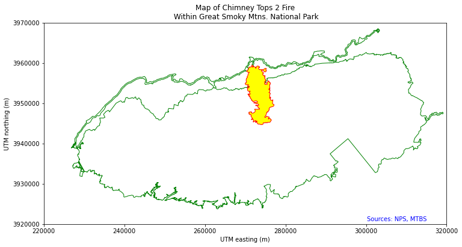

```python
# Plot the fire perimeter within the national park boundary
fig, ax = plt.subplots(figsize=(12, 8))

grsm_bound_reproj.plot(ax=ax,
                       color='white',
                       edgecolor='green')

chimney_fire_reproj.plot(ax=ax,
                         color='yellow',
                         edgecolor='red')

# Set figure title and axes
ax.set(
   title="Map of Chimney Tops 2 Fire\n Within Great Smoky Mtns. National Park",
   xlabel='UTM easting (m)',
   ylabel='UTM northing (m)')
ax.ticklabel_format(useOffset=False, style='plain')
ax.set(xlim=[220000, 320000], ylim=[3920000, 3970000])

# Data Source Caption
ax.text(.95, .01, "Sources: NPS, MTBS", va='bottom',
        ha='right', transform=ax.transAxes, color="blue")


# Turn off the axis
#plt.axis('equal')
#ax.set_axis_off()

plt.show()
```

- The Chimney Tops 2 Fire burned about 11,000 acres within Great Smoky Mountains National Park, only about 2% of the 500,000 acres within the park boundary. This map was created using the boundary of the Great Smoky National Park provided by the National Park Service (NPS) and the fire perimeter provided by the "Monitoring Trends in Burn Severity" program (MTBS).

## Objective #1: [Vegetation Analysis](https://www.earthdatascience.org/courses/use-data-open-source-python/multispectral-remote-sensing/vegetation-indices-in-python/)

We will use three different vegetation indices to evaluate the burned areas after the Chimney Tops 2 Fire.

## Selection of Bands for Vegetation Analysis

The NEON imaging spectrometer measures 426 bands in the range of 383.5343 - 2511.8945 nm, in which each band has a band width of 5 nm.

- For the calculation of NBR, we use band 117 for the NIR band and band 400 for the SWIR band. ([vanGerrevink et al., 2021](https://doi.org/10.3390/rs13224611))
- For the calculation of NDVI and MSAVI, we use band 58 for the Red band and band 84 for the NIR band. ([Meng et al., 2018](https://doi.org/10.1016/j.rse.2018.03.019))

```python
# Open NEON data and store reflectance array and metadata
post_fire_refl, post_fire_metadata = aop_h5refl2array(post_fire_path)
pre_fire_refl, pre_fire_metadata = aop_h5refl2array(pre_fire_path)
```

### We subset and stack these bands in the following order:

- Bands 58, 84, 117, 400; or Red, NIR (vegetation index), NIR (burn ratio), SWIR.

```python
# Stack and subset bands of interest
pre_fire_stack = stack_subset_bands(
    pre_fire_refl, pre_fire_metadata, (58, 84, 117, 400))
```

```python
post_fire_stack = stack_subset_bands(
    post_fire_refl, post_fire_metadata, (58, 84, 117, 400))
```

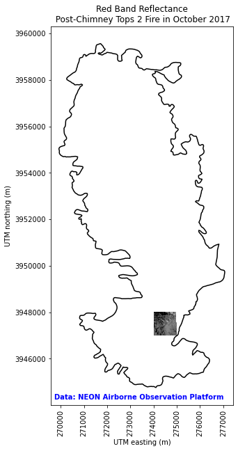

```python
# Plot an example reflectance tile within the fire boundary
f, ax = plt.subplots(figsize=(10, 10))

# Define raster image
plt.imshow(post_fire_refl[:, :, 0],
           extent=post_fire_metadata['extent'],
           cmap='Greys',
           clim=(0, 1200))

# Add fire boundary
chimney_fire_reproj.boundary.plot(ax=ax, color="black")

# Remove scientific notation from tile coordinates
ax.ticklabel_format(useOffset=False, style='plain')

# Set figure title and label axes
ax.set(title='Red Band Reflectance\n Post-Chimney Tops 2 Fire in October 2017',
       xlabel='UTM easting (m)',
       ylabel='UTM northing (m)')
rotatexlabels = plt.setp(ax.get_xticklabels(), rotation=90)

# Data source caption
ax.text(.95, .01, "Data: NEON Airborne Observation Platform", va='bottom',
        ha='right', transform=ax.transAxes, color="blue", fontweight='bold')

plt.show()
```

- The vegetation analysis below will be conducted on one specific reflectance tile using data collected by the NEON Airborne Observation Platform. Here is a map showing the location of the tile within the Chimney Tops 2 fire boundary. The fire boundary is sourced from the "Monitoring Trends in Burn Severity" program.

### 1. Normalized Burn Ratio (NBR)

- $NBR=\frac{(NIR-SWIR)}{(NIR+SWIR)}$
- The Difference Normalized Burn Ratio (dNBR) is the difference between the pre-fire NBR and the post-fire NBR.

```python
# Calculate NBR
post_fire_nbr = (
    post_fire_stack[:, :, 2] - post_fire_stack[:, :, 3]) / (
    post_fire_stack[:, :, 2] + post_fire_stack[:, :, 3])

pre_fire_nbr = (
    pre_fire_stack[:, :, 2] - pre_fire_stack[:, :, 3]) / (
    pre_fire_stack[:, :, 2] + pre_fire_stack[:, :, 3])

# Calculate dNBR
dnbr = pre_fire_nbr - post_fire_nbr
```

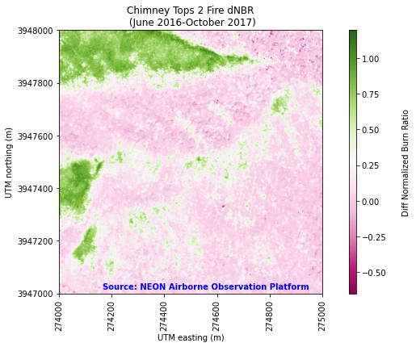

```python
# Plot dNBR
fig, ax = plt.subplots(figsize=(12, 6))

plot = ax.imshow(dnbr,
                  extent=post_fire_metadata['extent'],
                  cmap='PiYG')

# Color bar settings
cbar = plt.colorbar(plot, aspect=40)
cbar.set_label('Diff Normalized Burn Ratio', rotation=90, labelpad=20)

# Remove scientific notation from tile coordinates
ax.ticklabel_format(useOffset=False, style='plain')

# Set figure title and axes labels
ax.set(title='Chimney Tops 2 Fire dNBR\n (June 2016-October 2017)',
       xlabel='UTM easting (m)',
       ylabel='UTM northing (m)')
rotatexlabels = plt.setp(ax.get_xticklabels(), rotation=90)

# Data source caption
ax.text(.95, .01, "Source: NEON Airborne Observation Platform", va='bottom',
         ha='right', transform=ax.transAxes, color="blue", fontweight="bold")

plt.show()
```

- Here, we plot the difference normalized burn ratio of the Chimney Tops 2 Fire using reflectance data collected by the NEON Airborne Observation Platform. The plot of the difference between the pre-post NBR shows significant burned areas still exist almost one-year after the Chimney Tops 2 Fire. Regions above dNBR = 0.1 represent burn areas, whereas regions below dNBR = -0.1 represent regrowth.

### 2. Normalized Difference Vegetation Index (NDVI)

- $NDVI=\frac{(NIR-Red)}{(NIR+Red)}$
- The difference NDVI is the difference between the post-fire NDVI and the pre-fire NDVI.

```python
# Calculate NDVI using earthpy.spatial normalized_diff() function
post_fire_ndvi = es.normalized_diff(
    post_fire_stack[:,:,1], post_fire_stack[:,:,0])
pre_fire_ndvi = es.normalized_diff(
    pre_fire_stack[:,:,1], pre_fire_stack[:,:,0])

# Calculate diff NDVI
diff_ndvi = post_fire_ndvi - pre_fire_ndvi
```

### 3. Modified Soil Adjusted Vegetation Index (MSAVI)

- The MSAVI equation has been expanded for ease of computation from its original form of $\frac{2NIR+1-\sqrt{(2NIR + 1)^{2}-8(NIR-Red)}}{2}$ to $NIR+0.5-0.5\sqrt{4NIR^{2}-4NIR+8Red+1}$
- The difference MSAVI is the difference between the post-fire MSAVI and the pre-fire MSAVI.

```python
# Calculate MSAVI
pre_fire_msavi = pre_fire_stack[:,:,1] + 0.5 - 0.5 * (
    (4 * pre_fire_stack[:,:,1] * pre_fire_stack[:,:,1]) - (
     4 * pre_fire_stack[:,:,1]) + (
     8 * pre_fire_stack[:,:,0]) + 1)**(0.5)

post_fire_msavi = post_fire_stack[:,:,1] + 0.5 - 0.5 * (
    (4 * post_fire_stack[:,:,1] * post_fire_stack[:,:,1]) - (
     4 * post_fire_stack[:,:,1]) + (
     8 * post_fire_stack[:,:,0]) + 1)**(0.5)

# Calculate diff MSAVI
diff_msavi = post_fire_msavi - pre_fire_msavi
```

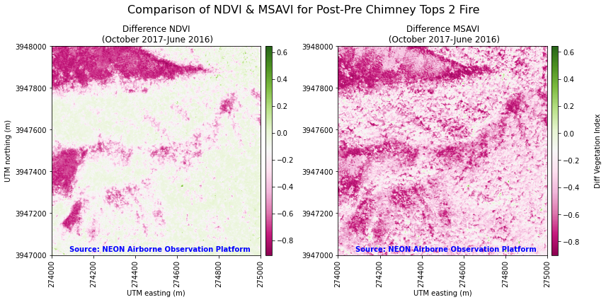

```python
# Plot diff NDVI and diff MSAVI together
fig, (ax1, ax2) = plt.subplots(1, 2, figsize=(12, 6))

plot1 = ax1.imshow(diff_ndvi,
                  extent=post_fire_metadata['extent'],
                  cmap='PiYG')

plot2 = ax2.imshow(diff_msavi,
                  extent=post_fire_metadata['extent'],
                  cmap='PiYG')

# Color bar settings
cbr = ep.colorbar(plot1)
cbar = ep.colorbar(plot2)
cbar.set_label('Diff Vegetation Index', rotation=90, labelpad=20)

# Remove scientific notation from tile coordinates
ax1.ticklabel_format(useOffset=False, style='plain')
ax2.ticklabel_format(useOffset=False, style='plain')

# Set figure title and axes labels
fig.suptitle(
    "Comparison of NDVI & MSAVI for Post-Pre Chimney Tops 2 Fire", fontsize=16)
ax1.set(title='Difference NDVI\n (October 2017-June 2016)',
        xlabel='UTM easting (m)',
        ylabel='UTM northing (m)')
rotatexlabels = plt.setp(ax1.get_xticklabels(), rotation=90)
ax2.set(title='Difference MSAVI\n (October 2017-June 2016)',
        xlabel='UTM easting (m)')
rotatexlabels = plt.setp(ax2.get_xticklabels(), rotation=90)

# Data source caption
ax1.text(.95, .01, "Source: NEON Airborne Observation Platform", va='bottom',
         ha='right', transform=ax1.transAxes, color="blue", fontweight="bold")
ax2.text(.95, .01, "Source: NEON Airborne Observation Platform", va='bottom',
         ha='right', transform=ax2.transAxes, color="blue", fontweight="bold")

fig.tight_layout()
plt.show()
```

## Objective #2: Quantify Key Variables of the Fire Environment

### Step 1: Determining wind direction and speed from RAWS site data

#### FW13 (RAWS data) file import/parsing

```
# Import data from .csv files
# Note data were downloaded as .csv in FW13 format
# and therefore require a bunch of parsing

fw13_ig = os.path.join("raws",
                     "raws-fw13-407603-11282016-hourly.csv")


ig = pd.read_csv(fw13_ig,header=None,sep='\s+',dtype='string')

#Label first iteration of columns (tab/space separated only)
ig.columns = ["Site-Date-Time", "DryBulb", "RH-Wind Az",
              "WndSpd", "MaxTemp","MinTemp", "MaxRH",
              "MinRH","PrecipDur","Precp Amt-Flag","HerbGreenness",
              "SG-MT-MT-SC","Solar Rad-Gust Az", "Gust Avg-N Flag"]

#Parse Site and DateTime data from combined strings
ig["Site"]=ig['Site-Date-Time'].str[3:9].astype(int)
ig["DateTime"]=ig['Site-Date-Time'].str[9:21]
ig['DateTime']=pd.to_datetime(ig['DateTime'],format='%Y%m%d%H%M', )
ig = ig.set_index('DateTime')

#Parse RH and Wind Azimuth from combined strings
ig["RH"]=ig['RH-Wind Az'].str[0:2].astype(int)
ig["WindAz"]=ig['RH-Wind Az'].str[2:5].astype(int)

ig["GustAz"]=ig['Solar Rad-Gust Az'].str.slice(start=-3).astype(int)
ig["Solar Rad"]=ig['Solar Rad-Gust Az'].str.slice(stop=-3).astype(int)

ig['GustSpd']=ig['Gust Avg-N Flag'].str.slice(stop=-1).astype(int)

ig["WndSpd"]=ig["WndSpd"].astype(int)

#Remake .df with key variables
ig_parsed = ig[['Site','WindAz','WndSpd','GustAz','GustSpd','DryBulb','RH']]

mean_wind_az = ig_parsed['WindAz'].mean().astype(int)
mean_gust_az = ig_parsed['GustAz'].mean().astype(int)
print("The mean wind/gust azimuths on Nov 28 were",
      mean_wind_az,"/",mean_gust_az,"degrees")
```

#### The mean wind/gust azimuths on Nov 28 were 196 / 206 degrees

#### Visualizing wind speed/direction for Nov 28- line plots

```
fig, (ax1, ax2, ax3) = plt.subplots(3, 1, figsize=(10, 10))
fig.suptitle(
    "Indian Grave RAWS Data November 28, 2016 ", fontsize=16)

# Top plot average wind azimuth
ig_parsed.plot(
    ax=ax1,
    y="WindAz",
    title="Hourly Average Wind Direction",
    color="grey",
    xlabel="Time",
    ylabel="Wind Azimuth (degrees)",
    ylim=(0,360),
    yticks=(45,90,135,180,225,270,315),
    grid=True,
    legend=None
)

# Middle plot
ig_parsed.plot(
    ax=ax2,
    y="GustAz",
    title="Hourly Wind Gust Direction",
    color="grey",
    xlabel="Time",
    ylabel="Wind Azimuth (degrees)",
    ylim=(0,360),
    yticks=(45,90,135,180,225,270,315),
    grid=True,
    legend=None
)

# Bottom plot monthly max values
ig_parsed.plot(
    ax=ax3,
    y="GustSpd",
    title="Hourly Average Wind Gust",
    color="grey",
    xlabel="Time",
    ylabel="Average Gust Speed (mph)",
    yticks=(10,20,30,40,50),
    grid=True,
    legend=None
)
# Set the date format with an object
date_form = DateFormatter("%H:%M")
ax1.xaxis.set_major_formatter(date_form)
ax2.xaxis.set_major_formatter(date_form)
ax3.xaxis.set_major_formatter(date_form)



plt.tight_layout()
plt.savefig('ig_raws.png', dpi=300)
```

[figure not shown]

- Time-series data from November 28, 2016 showing increase in generally southerly wind in late afternoon/early evening which corresponded with explosive fire behavior

#### Plotting wind and gust direction on rose diagram

Note: Eric adopted code from https://gist.github.com/phobson/41b41bdd157a2bcf6e14 to create the figures below

[figure not shown]

- Rose diagram showing hourly averaged wind gust vectors on November 28, 2016

### Step 2: Process LiDAR DTM tiles and clipped LANDFIRE grids for area of interest.

This step in progress- iteratively working on determining which DTM tiles make most sense to use. Had issues with GDAL this week after it working recently, so unable to readily do slope/aspect on DEM's. Code below for single tile test

```
# Designate working directory path as object.
mypath = os.path.join(et.io.HOME, 'earth-analytics',
                      'post-wildfire-vegetation-change','data')

dtm_test_path = os.path.join(mypath,'NEON_lidar-elev',
                        'NEON.D07.GRSM.DP3.30024.001.2018-05.basic.20220428T075908Z.RELEASE-2022',
                        'NEON_D07_GRSM_DP3_274000_3951000_DTM.tif')

# Create DEM object
dtm_test = rxr.open_rasterio(dtm_test_path, masked=True).squeeze()

# Plot
ep.plot_bands(dtm_test,
              title="274000 3951000",
              cmap="Greys")
plt.show()

# Calculate slope and aspect with rasterio
def calculate_slope(DEM):
    gdal.DEMProcessing('slope.tif', DEM, 'slope')
    with rasterio.open('slope.tif') as dataset:
        slope=dataset.read(1)
    return slope

def calculate_aspect(DEM):
    gdal.DEMProcessing('aspect.tif', DEM, 'aspect')
    with rasterio.open('aspect.tif') as dataset:
        aspect=dataset.read(1)
    return aspect

slope=calculate_slope('dtm_test')
aspect=calculate_aspect('dtm_test')
```

### Step 3: Raster processing to identify end members based on aspect, slope, and fuel conditions (i.e., LANDFIRE data)- waiting on successful execution of Step 2

### Step 4: Write code to plot variations in results from Step 3 (theoretical burn intensity) versus data collected for Objective #1 (post-fire recovery)- see excuse in Step 3 above!

## Summary and Future Directions

In this project, we aim to spatially quantify the vegetation recovery at 1-m spatial resolution, relate the variability in environmental fire effects, and relate these efforts towards each other. In this post, we have shown our first steps toward understanding the recovery after the Chimney Tops 2 Fire. With the vegetation analysis, we have found that even within one year after the fire, there are still significant burned areas within the Chimney Tops region. However, there is also evidence of regrowth, which in some areas may be minimal since the soil-noise background seems to be significant. For next steps, we will continue to survey the Chimney Tops region, and then we will compare the three vegetation indices and determine which best discriminates between unburned and burned areas using the Random Forest algorithm. Then we will use the NEON reflectance data and field data for vegetation type and cover for Great Smoky Mountains National Park ([NEON Plant presence and percent cover: DP1.10058.001](https://data.neonscience.org/data-products/DP1.10058.001/RELEASE-2022)) and build a spectral library in order to conduct a spectral band analysis. This will allow us to classify the components within the burned region into separate components and possibly identify vegetation species remotely.

## References

- Balch, J.K., Bradley, B.A., Abatzoglou, J.T., Nagy, R.C., Fusco, E.J. and Mahood, A.L., 2017. Human-started wildfires expand the fire niche across the United States. Proceedings of the National Academy of Sciences, 114(11), pp.2946-2951.
- Breiman, L. Random Forests. Machine Learning 45, 5–32 (2001). https://doi.org/10.1023/A:1010933404324
- Butler, B.W., Anderson, W.R. and Catchpole, E.A., 2007. Influence of slope on fire spread rate. In: Butler, Bret W.; Cook, Wayne, comps. The fire environment--innovations, management, and policy; conference proceedings. 26-30 March 2007; Destin, FL. Proceedings RMRS-P-46CD. Fort Collins, CO: US Department of Agriculture, Forest Service, Rocky Mountain Research Station. CD-ROM. p. 75-82 (Vol. 46).
- Calkin, D.E., Cohen, J.D., Finney, M.A. and Thompson, M.P., 2014. How risk management can prevent future wildfire disasters in the wildland-urban interface. Proceedings of the National Academy of Sciences, 111(2), pp.746-751.
- Glasspool, I.J., Edwards, D. and Axe, L., 2004. Charcoal in the Silurian as evidence for the earliest wildfire. Geology, 32(5), pp.381-383.
- He, Jiaying. 2018. Spatial and temporal patterns of vegetation disturbances in Great Smoky Mountains National Park. Master of Science, University of Georgia.
- Indian Grave Remote Automated Weather Station hourly data for November 2016. U.S. Forest Service Fire and Aviation Management Information Technology Portal. 2022. FW13 hourly station data (station ID:407603). Downloaded from https://famit.nwcg.gov/applications/FAMWeb on April 16, 2022.
- LANDFIRE: LANDFIRE Remap 2016 Biophysical Settings (BPS) CONUS layer.(2020, October - last update). U.S. Department of Interior, Geological Survey, and U.S. Department of Agriculture. Available: https://landfire.gov/bps.php. Data accessed April 3, 2022.
- LANDFIRE: LANDFIRE Remap 2016 Vegetation Departure grid (VDEP) CONUS layer.(2020, October - last update). U.S. Department of Interior, Geological Survey, and U.S. Department of Agriculture. Available: https://landfire.gov/vdep.php. Data accessed April 3, 2022.
- McLauchlan, K.K., Higuera, P.E., Miesel, J., Rogers, B.M., Schweitzer, J., Shuman, J.K., Tepley, A.J., Varner, J.M., Veblen, T.T., Adalsteinsson, S.A. and Balch, J.K., 2020. Fire as a fundamental ecological process: Research advances and frontiers. Journal of Ecology, 108(5), pp.2047-2069.
- Meng, R., Wu, J., Schwager, K. L., Zhao, F., Dennison, P. E., Cook, B. D., Brewster, K., Green, T. M., Serbin, S. P. 2017. Using high spatial resolution satellite imagery to map forest burn severity across spatial scales in a Pine Barrens ecosystem. Remote Sensing of Environment, 191, pp.95-109.
- Meng, R., Wu, J., Zhao, F., Cook, B. D., Hanavan, R. P., Serbin, S. P. 2018. Measuring short-term post-fire forest recovery across a burn severity gradient in a mixed pine-oak forest using multi-sensor remote sensing techniques. Remote Sensing of Environment. 210, 282-296.
- Monitoring Trends in Burn Severity (MTBS) Data Access: Fire Level Geospatial Data. (2022, February - last revised). MTBS Project (USDA Forest Service/U.S. Geological Survey). Available: http://mtbs.gov/direct-download. Data accessed April 3, 2022.
- National Ecological Observatory Network. Elevation - LiDAR (DP3.30024.001), RELEASE-2022. https://doi.org/10.48443/ymmp-fr93. Dataset accessed from https://data.neonscience.org on April 18, 2022
- National Ecological Observatory Network. Plant presence and percent cover (DP1.10058.001), RELEASE-2022. https://doi.org/10.48443/pr5e-1q60. Dataset accessed from https://data.neonscience.org on April 18, 2022.
- National Ecological Observatory Network. Spectrometer orthorectified surface directional reflectance - mosaic (DP3.30006.001), RELEASE-2022. https://doi.org/10.48443/5er3-8n49. Dataset accessed from https://data.neonscience.org on April 15, 2022.
- National Park Service- Land Resources Division. Great Smoky Mountains National Park Boundary. (December 30, 2019 - last revised). Available: https://grsm-nps.opendata.arcgis.com. Data accessed March 28, 2022.
- Qi, J.; Chehbouni, A.; Huete, A.; Kerr, Y., Sorooshian, S. A modified soil adjusted vegetation index. Remote Sensing of Environment. 1994, 48, 119-126. https://doi.org/10.1016/0034-4257(94)90134-1
- Seidl, R., Spies, T.A., Peterson, D.L., Stephens, S.L. and Hicke, J.A., 2016. Searching for resilience: addressing the impacts of changing disturbance regimes on forest ecosystem services. Journal of applied ecology, 53(1), pp.120-129.
- Spies, T.A., White, E.M., Kline, J.D., Fischer, A.P., Ager, A., Bailey, J., Bolte, J., Koch, J., Platt, E., Olsen, C.S. and Jacobs, D., 2014. Examining fire-prone forest landscapes as coupled human and natural systems. Ecology and Society, 19(3).
- vanGerrevink, M.J.; Veraverbeke, S. Evaluating the Hyperspectral Sensitivity of the Differenced Normalized Burn Ratio for Assessing Fire Severity. Remote Sensing. 2021, 13, 4611. https://doi.org/10.3390/rs13224611